# Multiple Myeloma Treatment Sequencing Model

Cost-Effectiveness Analysis; Model Run with User Inputs

06 February, 2024

# 1 Overview

This health economic simulation model is designed to estimate the course of disease, expected quality-adjusted life years (QALYs), and expected costs of multiple myeloma (MM) from a US healthcare perspective with three alternative sequences of treatment regimens for transplant-eligible patients. Based on these outcomes, a cost-effectiveness analysis is performed. Model inputs for the number of simulation runs, treatment effects expressed as hazard ratios (HR), utilities, drug treatment costs and other medical costs may be entered directly by the user. (Note: Only `R` chunks related to user input are visible in this Rmarkdown file. For a detailed description of the code, we refer the user to the `ModelDescription.Rmd` file. A detailed description of the model will be provided in a technical report.)

# 2 Treatment Sequences

The following treatment sequences are compared within the simulation model:

1. Sequence 1: (DVRd + ASCT + DR ) > DKd > EloPd > Sd > Cilta-cel.
2. Sequence 2: (DVRd + ASCT + DR ) > Cilta-cel > TalDara > Tec > SKd.
3. Sequence 3: (DVrd + DRd) > Tec > EloPd > Tal > Kd.

# 3 Model Structure

To estimate the course of disease, expected QALYs, and costs associated with the alternative treatment sequences, an individual-level continuous time state transition model is used (Figure 3.1).

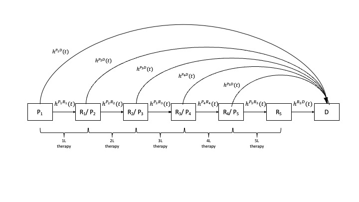

Figure 3.1: Model Structure

## 3.1 Model States

1. P1: On 1L therapy.
2. R1_P2: relapsed on 1L; moved to 2L therapy.
3. R2_P3: relapsed on 2L; moved to 3L therapy.
4. R3_P4: relapsed on 3L; moved to 4L therapy.
5. R4_P5: relapsed on 4L; moved to 5L therapy.
6. R5: relapsed on 5L therapy.
7. Death.

## 3.2 Transitions

The transitions between the model health states defined above are defined as follows:

Time-varying transition rates between the health states (lines of treatment) are based on progression free survival (PFS) curves from the following studies:

- Line 1, GRIFFIN (Voorhees et al. 2020),
- Line 2, CANDOR (Usmani et al. 2022),
- Line 3, ELOQUENT-3 (Dimopoulos et al. 2018),
- Line 4, STORM (Chari et al. 2019),
- Line 5, Majes TEC-1 (Moreau et al. 2022).

HR estimates will be applied to obtain time-varying transition rates for the actual treatments of interest by line of treatment for each of the sequences. Transition rates to death are based on overall survival (OS) data from (Braunlin et al. 2021) and US Life Tables.

# 4 Model Inputs (User Defined)

The user need to enter values in the code for the number of simulation runs, treatment effects expressed as HRs, utilities, drug treatment costs, and other medical costs.

## 4.1 Simulation Runs: Population Size and Number of Model Parameter Input Samples

The model is an individual-level simulation model by which disease progression over time and expected outcomes for the population of interest are obtained by repeatedly simulating individual patients for a given set of model input parameter values. The number of individuals simulated needs to be sufficiently large to minimize Monte Carlo error (or 1st order uncertainty) and obtain correct model output results for the set of input values. To propagate the uncertainty in model input parameters and reflect this in model output and cost-effectiveness results, the model repeatedly runs for different sets of randomly sampled input parameter values. A sufficiently large number of samples is needed to capture the complete uncertainty distributions of the model input parameters.

The user is able to set both the size of the simulated population for a given model run (with a given set of model input values) as well as the number of sampled sets of model input parameter values. NOTE: Increasing the simulated population size and the number of samples with different sets of input values will increase the time it takes to get model results.

- For a quick run and demonstration of the model it is sufficient to set `n_patients <- 100` and `n_samples <- 100`.
- For robust results, a `n_patients>=1000` and `n_samples>=1000` is recommended.

```r
# Simulation Runs ----
n_patients <- 200 # user: population size per set of parameter values
n_samples <- 300 # user: number of sampled sets of model input parameter values
```

## 4.2 Discount Rate, Willingness-to-Pay (CE Threshold), Anchor Sequence

```r
discQ <- 0.03       # user: QALY annual discount rate
discC <- 0.03       # user: Costs annual discount rate
anchor_seq <- 3    # user: anchor sequence strategy (comparator)
kwill <- 150000    # user: willingness to pay per QALY
```

## 4.3 Model Input Parameters

### 4.3.1 Disease Progression

#### 4.3.1.1 Hazard Ratios

The code below shows how the HRs (for time to progression) are entered based on the estimated range of uncertainty.

```r
# Sequence strategies
## st1 = Sequence 1
## st2 = Sequence 2
## st3 = Sequence 3
## notst3 = Either sequence 1 or 2
## notst2 = Either sequence 1 or 3

###########################################
## HRuser_modify = 0 use default HRs and uncertainty ranges;
## HRuser_modify = 1 enter HRs and uncertainty ranges
HRuser_modify = 1
if(HRuser_modify ==1){
kol.HR <- list(
  ## t1: "P1-> R1_P2"
  t1.hr = data.frame(low = c(notst3 = .21,  # DVRd + ASCT + DR. May be modified by user
                             st3 = 1        # DVrd + DRd. May be modified by user
                             ),
                     up = c( notst3 = .95,  # DVRd + ASCT + DR. May be modified by user
                             st3 = 1        # DVrd + DRd. May be modified by user
                            )),
  ## t3: "R1_P2 -> R2_P3"
  t3.hr = data.frame(low = c(st1 = 1,       # DKd. May be modified by user
                             st2= .66,      # Cilta-cel. May be modified by user
                             st3= 1         # Tec. May be modified by user
                             ),
                     up = c(st1 = 1,        # DKd. May be modified by user
                            st2 = 1.09,      # Cilta-cel. May be modified by user
                            st3 = 1         # Tec. May be modified by user
                            )),
  ## t5: "R2_P3 -> R3_P4"
  t5.hr = data.frame(low = c(notst2 = .96,    # EloPd. May be modified by user
                             st2= .4       # TalDara. May be modified by user
                             ),
                     up = c(notst2 = 1,     # EloPd. May be modified by user
                            st2 = .79       # TalDara. May be modified by user
                            )),
  ## t7: "R3_P4 -> R4_P5"
  t7.hr = data.frame(low = c(st1 = 1,       # Sd. May be modified by user
                             st2= .05,      # Tec. May be modified by user
                             st3= .16       # Tal. May be modified by user
                             ),
                     up = c(st1 = 1,        # Sd. May be modified by user
                            st2 = .11,      # Tec. May be modified by user
                            st3 = 1         # Tal. May be modified by user
                          )),
  ## t9: "R4_P5 -> R5"
  t9.hr = data.frame(low = c(st1 = .35,     # Cilta-cel. May be modified by user
                             st2= 1.51,      # SKd. May be modified by user
                             st3= 1.04       # Kd. May be modified by user
                             ),
                     up = c(st1 = .53,      # Cilta-cel. May be modified by user
                            st2= 2.21,       # SKd. May be modified by user
                            st3= 1.42        # Kd. May be modified by user
                            ))
)
} else{
  # HRuser_modify = 0, default baseline HRs and uncertainty ranges are used
  load('../data/kol.HR.rda')
}
```

#### 4.3.1.2 Mortality Adjustments

Choose the method to adjust the time to death pre-progression:

- Based on percentage of mortality up to median PFS: `OS_HR=0`.
- Based on percentage of mortality up to median OS: `OS_HR=1`.
- No adjustment: `OS_HR` not in $\{0,1\}$.

Choose source of mortality curves:

- Based on (Braunlin et al. 2021): `OS_Braunlin=1`.
- Based on US Life Tables: `OS_Braunlin=0`.

```r
OS_HR <- 0
OS_Braunlin <- 1
```

### 4.3.2 Utility

In the code below, utility input values are entered.

```r
# There are 6 non death states in the model:
## 1. P1: On 1L therapy.
## 2. R1_P2: relapsed on 1L; moved to 2L therapy.
## 3. R2_P3: relapsed on 2L; moved to 3L therapy.
## 4. R3_P4: relapsed on 3L; moved to 4L therapy.
## 5. R4_P5: relapsed on 4L; moved to 5L therapy.
## 6. R5: relapsed on 5L therapy.

###########################################
## user_modify = 0 use default HRs and uncertainty ranges;
## user_modify = 1 enter HRs and uncertainty ranges
user_modify = 1
if(user_modify ==1){
  ## Utilities
  util <- vector('list', length = 3)
  # sequence 1
  util[[1]] <- data.table(strategy_id =1,
                          state_id = state_ids,
                          mean = c(P1 = 0.659, # user
                                   R1_P2 = 0.626, # user
                                   R2_P3 = 0.599, # user
                                   R3_P4 = 0.599, # user
                                   R4_P5 = 0.599, # user
                                   R5 = 0.599 # user
                                   ),
                          se = c(P1 = 0.03475, # user
                                 R1_P2 = 0.02900, # user
                                 R2_P3 = 0.01425, # user
                                 R3_P4 = 0.07175, # user
                                 R4_P5 = 0.07175, # user
                                 R5 = 0.07175 # user
                                 )
                          )
  # sequence 2
  util[[2]] <- data.table(strategy_id =2,
                          state_id = state_ids,
                          mean = c(P1 = 0.659, # user
                                   R1_P2 = 0.626, # user
                                   R2_P3 = 0.599, # user
                                   R3_P4 = 0.599, # user
                                   R4_P5 = 0.599, # user
                                   R5 = 0.599 # user
                                   ),
                          se = c(P1 = 0.03475, # user
                                 R1_P2 = 0.02900, # user
                                 R2_P3 = 0.01425, # user
                                 R3_P4 = 0.07175, # user
                                 R4_P5 = 0.07175, # user
                                 R5 = 0.07175 # user
                                 )
                          )
  # sequence 3
  util[[3]] <- data.table(strategy_id =3,
                          state_id = state_ids,
                          mean = c(P1 = 0.659, # user
                                   R1_P2 = 0.626, # user
                                   R2_P3 = 0.599, # user
                                   R3_P4 = 0.599, # user
                                   R4_P5 = 0.599, # user
                                   R5 = 0.599 # user
                                   ),
                          se = c(P1 = 0.03475, # user
                                 R1_P2 = 0.02900, # user
                                 R2_P3 = 0.01425, # user
                                 R3_P4 = 0.07175, # user
                                 R4_P5 = 0.07175, # user
                                 R5 = 0.07175 # user
                                 )
                          )
  utility_data <- do.call(rbind, util)
  rm(util)
  } else{
    # user_modify = 0, baseline utilities are used
    load('../data/utility_data.rda')
    }
```

### 4.3.3 Other Medical costs

In the code below, other medical costs are entered.

#### 4.3.3.1 Inpatient Costs

```r
# States
## 1. P1: On 1L therapy.
## 2. R1_P2: relapsed on 1L; moved to 2L therapy.
## 3. R2_P3: relapsed on 2L; moved to 3L therapy.
## 4. R3_P4: relapsed on 3L; moved to 4L therapy.
## 5. R4_P5: relapsed on 4L; moved to 5L therapy.
## 6. R5: relapsed on 5L therapy.

###########################################
## ipa_user_modify = 0 use baseline inpatient costs;
## ipa_user_modify = 1 enter use baseline inpatient costs
ipa_user_modify = 1
if(ipa_user_modify ==1){
  ## Inpatient
  ipa <- vector('list', length = 3)
  ### sequence 1
  ipa[[1]] <- data.table(strategy_id = 1,
                         # Excludes state R5
                         state_id = state_ids[1:5],
                         mean = c(P1 = 29089.71, # user
                                  R1_P2 = 52876.24, # user
                                  R2_P3 = 97455.06, # user
                                  R3_P4 = 115083.54, # user
                                  R4_P5 = 135900.80 # user
                                  ),
                         se = c(P1 = 4601.797, # user
                                R1_P2 = 5990.687, # user
                                R2_P3 = 10984.061, # user
                                R3_P4 = 19727.341, # user
                                R4_P5 = 18003.367 # user
                                )
                       )
  ### sequence 2
  ipa[[2]] <- data.table(strategy_id = 2,
                         # Excludes state R5
                         state_id = state_ids[1:5],
                         mean = c(P1 = 29089.71, # user
                                  R1_P2 = 52876.24, # user
                                  R2_P3 = 97455.06, # user
                                  R3_P4 = 115083.54, # user
                                  R4_P5 = 135900.80 # user
                                  ),
                         se = c(P1 = 4601.797, # user
                                R1_P2 = 5990.687, # user
                                R2_P3 = 10984.061, # user
                                R3_P4 = 19727.341, # user
                                R4_P5 = 18003.367 # user
                                )
                       )
  ### sequence 3
  ipa[[3]] <- data.table(strategy_id = 3,
                         state_id = state_ids[1:5],
                         # Excludes state R5
                         mean = c(P1 = 29089.71, # user
                                  R1_P2 = 52876.24, # user
                                  R2_P3 = 97455.06, # user
                                  R3_P4 = 115083.54, # user
                                  R4_P5 = 135900.80 # user
                                  ),
                         se = c(P1 = 4601.797, # user
                                R1_P2 = 5990.687, # user
                                R2_P3 = 10984.061, # user
                                R3_P4 = 19727.341, # user
                                R4_P5 = 18003.367 # user
                                )
                       )
  inpatient <- do.call(rbind, ipa)
  rm(ipa)
  } else{
    # ipa_user_modify = 0, baseline inpatient costs are used
    load('../data/medcost_data.rda')
    inpatient <- medcost_data$inpatient
    rm(medcost_data)
  }
```

#### 4.3.3.2 Outpatient Costs

```r
# States
## 1. P1: On 1L therapy.
## 2. R1_P2: relapsed on 1L; moved to 2L therapy.
## 3. R2_P3: relapsed on 2L; moved to 3L therapy.
## 4. R3_P4: relapsed on 3L; moved to 4L therapy.
## 5. R4_P5: relapsed on 4L; moved to 5L therapy.
## 6. R5: relapsed on 5L therapy.

###########################################
## op_user_modify = 0 use baseline outpatient costs;
## op_user_modify = 1 enter use baseline outpatient costs

op_user_modify = 1
if(op_user_modify ==1){
  ## Outpatient
  outpat <- vector('list', length = 3)
  ### sequence 1
  outpat[[1]] <- data.table(strategy_id = 1,
                            # Excludes state R5
                            state_id = state_ids[1:5],
                            mean = c(P1 = 26368.82, # user
                                     R1_P2 = 42602.41, # user
                                     R2_P3 = 64461.73, # user
                                     R3_P4 = 59304.77, # user
                                     R4_P5 = 54560.36 # user
                                     ),
                            se = c(P1 = 1483.823, # user
                                   R1_P2 = 3503.257, # user
                                   R2_P3 = 4051.651, # user
                                   R3_P4 = 5768.380, # user
                                   R4_P5 = 4407.599 # user
                                   )
                       )
  ### sequence 2
  outpat[[2]] <- data.table(strategy_id = 2,
                            # Excludes state R5
                            state_id = state_ids[1:5],
                            mean = c(P1 = 26368.82, # user
                                     R1_P2 = 42602.41, # user
                                     R2_P3 = 64461.73, # user
                                     R3_P4 = 59304.77, # user
                                     R4_P5 = 54560.36 # user
                                     ),
                            se = c(P1 = 1483.823, # user
                                   R1_P2 = 3503.257, # user
                                   R2_P3 = 4051.651, # user
                                   R3_P4 = 5768.380, # user
                                   R4_P5 = 4407.599 # user
                                   )
                       )
  ### sequence 3
  outpat[[3]] <- data.table(strategy_id = 3,
                            # Excludes state R5
                            state_id = state_ids[1:5],
                            mean = c(P1 = 26368.82, # user
                                     R1_P2 = 42602.41, # user
                                     R2_P3 = 64461.73, # user
                                     R3_P4 = 59304.77, # user
                                     R4_P5 = 54560.36 # user
                                     ),
                            se = c(P1 = 1483.823, # user
                                   R1_P2 = 3503.257, # user
                                   R2_P3 = 4051.651, # user
                                   R3_P4 = 5768.380, # user
                                   R4_P5 = 4407.599 # user
                                   )
                       )
  outpatient <- do.call(rbind, outpat)
  rm(outpat)
  } else{
    # op_user_modify = 0, baseline outpatient costs are used
    load('../data/medcost_data.rda')
    outpatient <- medcost_data$outpatient
    rm(medcost_data)
  }
```

#### 4.3.3.3 Other Outpatient Costs

```r
# States
## 1. P1: On 1L therapy.
## 2. R1_P2: relapsed on 1L; moved to 2L therapy.
## 3. R2_P3: relapsed on 2L; moved to 3L therapy.
## 4. R3_P4: relapsed on 3L; moved to 4L therapy.
## 5. R4_P5: relapsed on 4L; moved to 5L therapy.
## 6. R5: relapsed on 5L therapy.

###########################################
## user_modify = 0 use baseline outpatient costs;
## user_modify = 1 enter use baseline outpatient costs

othop_user_modify = 1
if(othop_user_modify ==1){
  ## Other outpatient
  oth_op <- vector('list', length = 3)
  ### sequence 1
  oth_op[[1]] <- data.table(strategy_id = 1,
                            # Excludes state R5
                            state_id = state_ids[1:5],
                            mean = c(P1 = 11336.85, # user
                                     R1_P2 = 12989.16, # user
                                     R2_P3 = 19559.52, # user
                                     R3_P4 = 21475.06, # user
                                     R4_P5 = 23578.20 # user
                                     ),
                            se = c(P1 = 1176.5551, # user
                                   R1_P2 = 981.9048, # user
                                   R2_P3 = 2077.8947, # user
                                   R3_P4 = 4159.3015, # user
                                   R4_P5 = 2951.2769 # user
                            )
                       )
  ### sequence 2
  oth_op[[2]] <- data.table(strategy_id = 2,
                            # Excludes state R5
                            state_id = state_ids[1:5],
                            mean = c(P1 = 11336.85, # user
                                     R1_P2 = 12989.16, # user
                                     R2_P3 = 19559.52, # user
                                     R3_P4 = 21475.06, # user
                                     R4_P5 = 23578.20 # user
                                     ),
                            se = c(P1 = 1176.5551, # user
                                   R1_P2 = 981.9048, # user
                                   R2_P3 = 2077.8947, # user
                                   R3_P4 = 4159.3015, # user
                                   R4_P5 = 2951.2769 # user
                            )
                       )
  ### sequence 3
  oth_op[[3]] <- data.table(strategy_id = 3,
                            # Excludes state R5
                            state_id = state_ids[1:5],
                            mean = c(P1 = 11336.85, # user
                                     R1_P2 = 12989.16, # user
                                     R2_P3 = 19559.52, # user
                                     R3_P4 = 21475.06, # user
                                     R4_P5 = 23578.20 # user
                                     ),
                            se = c(P1 = 1176.5551, # user
                                   R1_P2 = 981.9048, # user
                                   R2_P3 = 2077.8947, # user
                                   R3_P4 = 4159.3015, # user
                                   R4_P5 = 2951.2769 # user
                            )
                       )
  other_outpatient_drugs <- do.call(rbind, oth_op)
  rm(oth_op)
  } else{
    # othop_user_modify = 0, baseline other outpatient costs are used
    load('../data/medcost_data.rda')
    other_outpatient_drugs <- medcost_data$other_outpatient_drugs
    rm(medcost_data)
  }
```

#### 4.3.3.4 Hospice Costs (Line of Treatment 5+)

```r
# States
## 1. P1: On 1L therapy.
## 2. R1_P2: relapsed on 1L; moved to 2L therapy.
## 3. R2_P3: relapsed on 2L; moved to 3L therapy.
## 4. R3_P4: relapsed on 3L; moved to 4L therapy.
## 5. R4_P5: relapsed on 4L; moved to 5L therapy.
## 6. R5: relapsed on 5L therapy.

###########################################
## user_modify = 0 use baseline hospice costs;
## user_modify = 1 enter use baseline hospice costs

hosp_user_modify = 1
if(hosp_user_modify ==1){
  ## Hospice
  hosp <- vector('list', length = 3)
  ### sequence 1
  hosp[[1]] <- data.table(strategy_id = 1,
                          # Only state R5
                          state_id = state_ids[length(state_ids)],
                          mean = c(R5 = 115972.9 # user
                                   ),
                          se = c(R5 = 28993.22 # user
                                 )
                          )
  ### sequence 2
  hosp[[2]] <- data.table(strategy_id = 2,
                          # Only state R5
                          state_id = state_ids[length(state_ids)],
                          mean = c(R5 = 115972.9 # user
                                   ),
                          se = c(R5 = 28993.22 # user
                                 )
                          )
  ### sequence 3
  hosp[[3]] <- data.table(strategy_id = 3,
                          # Only state R5
                          state_id = state_ids[length(state_ids)],
                          mean = c(R5 = 115972.9 # user
                                   ),
                          se = c(R5 = 28993.22 # user
                                 )
                          )
  hospice <- do.call(rbind, hosp)
  rm(hosp)
} else{
  # hosp_user_modify = 0, baseline hospice costs are used
  load('../data/medcost_data.rda')
  hospice <- medcost_data$hospice
  rm(medcost_data)
}
```

### 4.3.4 Drug Treatment Costs

Cost of drug per mg.

```r
# user_modify = 0 uses baseline treatment cost;
# user_modify = 1 uses values given by user.

user_modify <- 1
if( user_modify == 1){
  ## Cost are in USD/mg
  drug_cost <- c(
    Bortezomib = 74.11, # user
    Daratumumab = 6.69, # user
    Lenalidomide = 73.19, # user
    Dexamethasone = 0.56, # user
    ASCT = 109577, # user
    Melphalan = 20.00, # user
    Carfilzomib = 49.7, # user
    Teclistamab = 59, # user
    `Cilta-cel` =  478950, # user
    Elotuzumab = 7.15, # user
    Pomalidomide = 537, # user
    Talquetamab = 259, # user
    Selinexor = 91,  # user
    Admin = 614.10 # user
    )
  } else {
    # baseline WAC are used if user_modify =0
    load('../data/base_wac.rda')
    drug_cost <- base_wac$WAC
    names(drug_cost) <- base_wac$Rx
    rm(base_wac)
  }
```

## 4.4 Set Output File Names

- When knitting an R markdown file (.Rmd), the working directory is the one that contains the markdown file. For example, the working directory of the present markdown is /Users/odiaz/MMModel/analysis.
- Figures and tables with model results are saved in the output directory set by the user.
- We recommend creating a dedicated output directory.

```r
# Names of the dedicated output directory and file names must not have spaces

## Default output path.
outputdir <- 'output'

## Name of Excel file where output tables for time to progression (TTP)
## and time to death pre-progression are saved
progression_tbl <- 'progressionTbl.xlsx'

## Name of file where curve for PFS is saved
survePFSline1File <- 'pfs1stline.pdf'

## Name of file where curve for OS from second line survival is saved
surveOSline1File <- 'os1stline.pdf'

## Name of file where curve for PFS at second line survival is saved
survePFSline2File <- 'pfs2ndline.pdf'

## Name of file where curve for TTP at second line survival is saved
surveTTPline2File <- 'ttp2ndline.pdf'

## Name of file where curve for OS from second line survival is saved
surveOSline2File <- 'os2ndline.pdf'

## Name of 'pdf' file where the plot for state probabilities is saved
state_probFile <- 'stprobs.pdf'

## Names of files where charts with economic outputs are saved
qalys_nm <- 'qalys.pdf'
txcosts_nm <- 'txcosts.pdf'
medcosts_nm <- 'medcosts.pdf'
totcosts_nm <- 'totcosts.pdf'

# Name of file where the data needed to create economic charts is saved
chart_data_nm <- 'chart_data.xlsx'

## Name of file where the  summary statistics of economic outputs are saved
ecoSummary <- 'ce_sim_output.xlsx'

## Name of file where cea output is saved
cea_output <- "cea_output.xlsx"
```

# 5 Overview Model Input Parameters

## 5.1 Hazard Ratios

Table 5.1 displays the HRs (as uncertainty ranges) that will be applied to reference PFS curves

Table 5.1: Table 5.2: Hazard ratio for each treatment

| Sequence | Treatment | Transition | low | up |
| --- | --- | --- | --- | --- |
| Not 3 | DVRd + ASCT + DR | P1-> R1_P2 | 0.21 | 0.95 |
| 3 | DVrd + DRd | P1-> R1_P2 | 1.00 | 1.00 |
| Not 3 | DVRd + ASCT + DR | P1 -> Death | 0.56 | 0.97 |
| 3 | DVrd + DRd | P1 -> Death | 1.00 | 1.00 |
| 1 | DKd | R1_P2 -> R2_P3 | 1.00 | 1.00 |
| 2 | Cilta-cel | R1_P2 -> R2_P3 | 0.66 | 1.09 |
| 3 | Tec | R1_P2 -> R2_P3 | 1.00 | 1.00 |
| 1 | DKd | R1_P2 -> Death | 1.00 | 1.00 |
| 2 | Cilta-cel | R1_P2 -> Death | 0.76 | 1.06 |
| 3 | Tec | R1_P2 -> Death | 1.00 | 1.00 |
| Not 2 | EloPd | R2_P3 -> R3_P4 | 0.96 | 1.00 |
| 2 | TalDara | R2_P3 -> R3_P4 | 0.40 | 0.79 |
| Not 2 | EloPd | R2_P3 -> Death | 0.97 | 1.00 |
| 2 | TalDara | R2_P3 -> Death | 0.50 | 0.82 |
| 1 | Sd | R3_P4 -> R4_P5 | 1.00 | 1.00 |
| 2 | Tec | R3_P4 -> R4_P5 | 0.05 | 0.11 |
| 3 | Tal | R3_P4 -> R4_P5 | 0.16 | 1.00 |
| 1 | Sd | R3_P4 -> Death | 1.00 | 1.00 |
| 2 | Tec | R3_P4 -> Death | 0.14 | 0.20 |
| 3 | Tal | R3_P4 -> Death | 0.24 | 1.00 |
| 1 | Cilta-cel | R4_P5 -> R5 | 0.35 | 0.53 |
| 2 | SKd | R4_P5 -> R5 | 1.51 | 2.21 |
| 3 | Kd | R4_P5 -> R5 | 1.04 | 1.42 |
| 1 | Cilta-cel | R4_P5 -> Death | 0.44 | 0.60 |
| 2 | SKd | R4_P5 -> Death | 1.44 | 2.04 |
| 3 | Kd | R4_P5 -> Death | 1.03 | 1.36 |
| 1 | Paliative | R5 -> Death | 1.05 | 1.10 |
| 2 | Paliative | R5 -> Death | 1.05 | 1.10 |
| 3 | Paliative | R5 -> Death | 1.05 | 1.10 |

## 5.2 Utility

Table 5.3: Table 5.4: Utility values used in the model

| strategy_id | state_id | state | mean | se |
| --- | --- | --- | --- | --- |
| 1 | 1 | P1 | 0.659 | 0.03475 |
| 1 | 2 | R1_P2 | 0.626 | 0.02900 |
| 1 | 3 | R2_P3 | 0.599 | 0.01425 |
| 1 | 4 | R3_P4 | 0.599 | 0.07175 |
| 1 | 5 | R4_P5 | 0.599 | 0.07175 |
| 1 | 6 | R5 | 0.599 | 0.07175 |
| 2 | 1 | P1 | 0.659 | 0.03475 |
| 2 | 2 | R1_P2 | 0.626 | 0.02900 |
| 2 | 3 | R2_P3 | 0.599 | 0.01425 |
| 2 | 4 | R3_P4 | 0.599 | 0.07175 |
| 2 | 5 | R4_P5 | 0.599 | 0.07175 |
| 2 | 6 | R5 | 0.599 | 0.07175 |
| 3 | 1 | P1 | 0.659 | 0.03475 |
| 3 | 2 | R1_P2 | 0.626 | 0.02900 |
| 3 | 3 | R2_P3 | 0.599 | 0.01425 |
| 3 | 4 | R3_P4 | 0.599 | 0.07175 |
| 3 | 5 | R4_P5 | 0.599 | 0.07175 |
| 3 | 6 | R5 | 0.599 | 0.07175 |

## 5.3 Other Medical Costs

### 5.3.1 Inpatient Costs

Table 5.5: Table 5.6: Inpatient cost by strategy and health state as used in the model

| strategy_id | state_id | state | mean | se |
| --- | --- | --- | --- | --- |
| 1 | 1 | P1 | 29089.71 | 4601.797 |
| 1 | 2 | R1_P2 | 52876.24 | 5990.687 |
| 1 | 3 | R2_P3 | 97455.06 | 10984.061 |
| 1 | 4 | R3_P4 | 115083.54 | 19727.341 |
| 1 | 5 | R4_P5 | 135900.80 | 18003.367 |
| 1 | 6 | R5 | 0.00 | 0.000 |
| 2 | 1 | P1 | 29089.71 | 4601.797 |
| 2 | 2 | R1_P2 | 52876.24 | 5990.687 |
| 2 | 3 | R2_P3 | 97455.06 | 10984.061 |
| 2 | 4 | R3_P4 | 115083.54 | 19727.341 |
| 2 | 5 | R4_P5 | 135900.80 | 18003.367 |
| 2 | 6 | R5 | 0.00 | 0.000 |
| 3 | 1 | P1 | 29089.71 | 4601.797 |
| 3 | 2 | R1_P2 | 52876.24 | 5990.687 |
| 3 | 3 | R2_P3 | 97455.06 | 10984.061 |
| 3 | 4 | R3_P4 | 115083.54 | 19727.341 |
| 3 | 5 | R4_P5 | 135900.80 | 18003.367 |
| 3 | 6 | R5 | 0.00 | 0.000 |

### 5.3.2 Outpatient Costs

Table 5.7: Table 5.8: Outpatient costs by strategy and health state as used in the model

| strategy_id | state_id | state | mean | se |
| --- | --- | --- | --- | --- |
| 1 | 1 | P1 | 26368.82 | 1483.823 |
| 1 | 2 | R1_P2 | 42602.41 | 3503.257 |
| 1 | 3 | R2_P3 | 64461.73 | 4051.651 |
| 1 | 4 | R3_P4 | 59304.77 | 5768.380 |
| 1 | 5 | R4_P5 | 54560.36 | 4407.599 |
| 1 | 6 | R5 | 0.00 | 0.000 |
| 2 | 1 | P1 | 26368.82 | 1483.823 |
| 2 | 2 | R1_P2 | 42602.41 | 3503.257 |
| 2 | 3 | R2_P3 | 64461.73 | 4051.651 |
| 2 | 4 | R3_P4 | 59304.77 | 5768.380 |
| 2 | 5 | R4_P5 | 54560.36 | 4407.599 |
| 2 | 6 | R5 | 0.00 | 0.000 |
| 3 | 1 | P1 | 26368.82 | 1483.823 |
| 3 | 2 | R1_P2 | 42602.41 | 3503.257 |
| 3 | 3 | R2_P3 | 64461.73 | 4051.651 |
| 3 | 4 | R3_P4 | 59304.77 | 5768.380 |
| 3 | 5 | R4_P5 | 54560.36 | 4407.599 |
| 3 | 6 | R5 | 0.00 | 0.000 |

### 5.3.3 Other Outpatient Costs

Table 5.9: Table 5.10: Other outpatient costs by strategy and health state as used in the model

| strategy_id | state_id | state | mean | se |
| --- | --- | --- | --- | --- |
| 1 | 1 | P1 | 11336.85 | 1176.5551 |
| 1 | 2 | R1_P2 | 12989.16 | 981.9048 |
| 1 | 3 | R2_P3 | 19559.52 | 2077.8947 |
| 1 | 4 | R3_P4 | 21475.06 | 4159.3015 |
| 1 | 5 | R4_P5 | 23578.20 | 2951.2769 |
| 1 | 6 | R5 | 0.00 | 0.0000 |
| 2 | 1 | P1 | 11336.85 | 1176.5551 |
| 2 | 2 | R1_P2 | 12989.16 | 981.9048 |
| 2 | 3 | R2_P3 | 19559.52 | 2077.8947 |
| 2 | 4 | R3_P4 | 21475.06 | 4159.3015 |
| 2 | 5 | R4_P5 | 23578.20 | 2951.2769 |
| 2 | 6 | R5 | 0.00 | 0.0000 |
| 3 | 1 | P1 | 11336.85 | 1176.5551 |
| 3 | 2 | R1_P2 | 12989.16 | 981.9048 |
| 3 | 3 | R2_P3 | 19559.52 | 2077.8947 |
| 3 | 4 | R3_P4 | 21475.06 | 4159.3015 |
| 3 | 5 | R4_P5 | 23578.20 | 2951.2769 |
| 3 | 6 | R5 | 0.00 | 0.0000 |

### 5.3.4 Hospice Costs

Table 5.11: Table 5.12: Hospice costs (only after line 5) as used in the model

| strategy_id | state_id | state | mean | se |
| --- | --- | --- | --- | --- |
| 1 | 1 | P1 | 0.0 | 0.00 |
| 1 | 2 | R1_P2 | 0.0 | 0.00 |
| 1 | 3 | R2_P3 | 0.0 | 0.00 |
| 1 | 4 | R3_P4 | 0.0 | 0.00 |
| 1 | 5 | R4_P5 | 0.0 | 0.00 |
| 1 | 6 | R5 | 115972.9 | 28993.22 |
| 2 | 1 | P1 | 0.0 | 0.00 |
| 2 | 2 | R1_P2 | 0.0 | 0.00 |
| 2 | 3 | R2_P3 | 0.0 | 0.00 |
| 2 | 4 | R3_P4 | 0.0 | 0.00 |
| 2 | 5 | R4_P5 | 0.0 | 0.00 |
| 2 | 6 | R5 | 115972.9 | 28993.22 |
| 3 | 1 | P1 | 0.0 | 0.00 |
| 3 | 2 | R1_P2 | 0.0 | 0.00 |
| 3 | 3 | R2_P3 | 0.0 | 0.00 |
| 3 | 4 | R3_P4 | 0.0 | 0.00 |
| 3 | 5 | R4_P5 | 0.0 | 0.00 |
| 3 | 6 | R5 | 115972.9 | 28993.22 |

## 5.4 Drug Treatment Costs

### 5.4.1 Sequence 1

Table 5.13: Table 5.14: Annualized drug treatment costs as used in the model for treatment sequence 1.

| Sequence | LOT | Rx | Drug_Cost_Code | Cost | t_init | t_stop |
| --- | --- | --- | --- | --- | --- | --- |
| 1 | 1 | Daratumumab | 1_DVRd + ASCT + DR_Cycle1_D | 313952.14 | 0.000 | 0.077 |
| 1 | 1 | Daratumumab | 1_DVRd + ASCT + DR_Cycle2_D | 313952.14 | 0.079 | 0.156 |
| 1 | 1 | Daratumumab | 1_DVRd + ASCT + DR_Cycle3_D | 313952.14 | 0.159 | 0.236 |
| 1 | 1 | Daratumumab | 1_DVRd + ASCT + DR_Cycle5_D | 104650.71 | 0.318 | 0.395 |
| 1 | 1 | Daratumumab | 1_DVRd + ASCT + DR_Cycle6_D | 104650.71 | 0.397 | 0.474 |
| 1 | 1 | Daratumumab | 1_DVRd + ASCT + DR_Cycle7+_D | 104650.71 | 0.477 | 99.000 |
| 1 | 1 | Bortezomib | 1_DVRd + ASCT + DR_Cycle1_V | 8540.12 | 0.000 | 0.077 |
| 1 | 1 | Lenalidomide | 1_DVRd + ASCT + DR_Cycle1_R | 333929.38 | 0.000 | 0.077 |
| 1 | 1 | Lenalidomide | 1_DVRd + ASCT + DR_Cycle7_R | 200357.63 | 0.477 | 0.553 |
| 1 | 1 | Lenalidomide | 1_DVRd + ASCT + DR_Cycle8_R | 200357.63 | 0.556 | 0.633 |
| 1 | 1 | Lenalidomide | 1_DVRd + ASCT + DR_Cycle9_R | 200357.63 | 0.636 | 0.712 |
| 1 | 1 | Lenalidomide | 1_DVRd + ASCT + DR_Cycle10+_R | 300536.44 | 0.715 | 99.000 |
| 1 | 1 | Dexamethasone | 1_DVRd + ASCT + DR_Cycle1_De | 1489.20 | 0.000 | 0.077 |
| 1 | 1 | Melphalan | 1_DVRd + ASCT + DR_Cycle4_Mel | 6800.00 | 0.238 | 0.238 |
| 1 | 1 | ASCT | 1_DVRd + ASCT + DR_Cycle4_ASCT | 109577.00 | 0.238 | 0.238 |
| 1 | 1 | Admin | 1_DVRd + ASCT + DR_Cycle1_Adm | 40026.16 | 0.000 | 0.077 |
| 1 | 1 | Admin | 1_DVRd + ASCT + DR_Cycle2_Adm | 24015.70 | 0.079 | 0.156 |
| 1 | 1 | Admin | 1_DVRd + ASCT + DR_Cycle3_Adm | 24015.70 | 0.159 | 0.236 |
| 1 | 1 | Admin | 1_DVRd + ASCT + DR_Cycle4_Adm | 614.10 | 0.238 | 0.238 |
| 1 | 1 | Admin | 1_DVRd + ASCT + DR_Cycle5_Adm | 8005.23 | 0.318 | 0.395 |
| 1 | 1 | Admin | 1_DVRd + ASCT + DR_Cycle6_Adm | 8005.23 | 0.397 | 0.474 |
| 1 | 1 | Admin | 1_DVRd + ASCT + DR_Cycle7+_Adm | 8005.23 | 0.477 | 99.000 |
| 1 | 2 | Daratumumab | 2_DKd_Cycle1_D | 418602.86 | 0.000 | 0.077 |
| 1 | 2 | Daratumumab | 2_DKd_Cycle2_D | 418602.86 | 0.079 | 0.156 |
| 1 | 2 | Daratumumab | 2_DKd_Cycle3_D | 209301.43 | 0.159 | 0.236 |
| 1 | 2 | Daratumumab | 2_DKd_Cycle4_D | 209301.43 | 0.238 | 0.315 |
| 1 | 2 | Daratumumab | 2_DKd_Cycle5_D | 209301.43 | 0.318 | 0.395 |
| 1 | 2 | Daratumumab | 2_DKd_Cycle6_D | 209301.43 | 0.397 | 0.474 |
| 1 | 2 | Daratumumab | 2_DKd_Cycle7+_D | 104650.71 | 0.477 | 99.000 |
| 1 | 2 | Carfilzomib | 2_DKd_Cycle1_K | 229088.60 | 0.000 | 0.077 |
| 1 | 2 | Carfilzomib | 2_DKd_Cycle2+_K | 308388.50 | 0.079 | 99.000 |
| 1 | 2 | Dexamethasone | 2_DKd_Cycle1+_De | 1985.60 | 0.000 | 99.000 |
| 1 | 2 | Admin | 2_DKd_Cycle1_Adm | 32020.93 | 0.000 | 0.077 |
| 1 | 2 | Admin | 2_DKd_Cycle1+_Adm | 16010.46 | 0.000 | 99.000 |
| 1 | 2 | Admin | 2_DKd_Cycle2_Adm | 8005.23 | 0.079 | 0.156 |
| 1 | 2 | Admin | 2_DKd_Cycle2+_Adm | 32020.93 | 0.079 | 99.000 |
| 1 | 2 | Admin | 2_DKd_Cycle3_Adm | 16010.46 | 0.159 | 0.236 |
| 1 | 2 | Admin | 2_DKd_Cycle4_Adm | 16010.46 | 0.238 | 0.315 |
| 1 | 2 | Admin | 2_DKd_Cycle5_Adm | 16010.46 | 0.318 | 0.395 |
| 1 | 2 | Admin | 2_DKd_Cycle6_Adm | 16010.46 | 0.397 | 0.474 |
| 1 | 2 | Admin | 2_DKd_Cycle7+_Adm | 8005.23 | 0.477 | 99.000 |
| 1 | 3 | Elotuzumab | 3_EloPd_Cycle1_Elo | 279616.07 | 0.000 | 0.077 |
| 1 | 3 | Elotuzumab | 3_EloPd_Cycle2_Elo | 279616.07 | 0.079 | 0.156 |
| 1 | 3 | Elotuzumab | 3_EloPd_Cycle3+_Elo | 139808.04 | 0.159 | 99.000 |
| 1 | 3 | Pomalidomide | 3_EloPd_Cycle1+_P | 588015.00 | 0.000 | 99.000 |
| 1 | 3 | Dexamethasone | 3_EloPd_Cycle1_De | 1389.92 | 0.000 | 0.077 |
| 1 | 3 | Dexamethasone | 3_EloPd_Cycle2_De | 1389.92 | 0.079 | 0.156 |
| 1 | 3 | Dexamethasone | 3_EloPd_Cycle3+_De | 347.48 | 0.159 | 99.000 |
| 1 | 3 | Admin | 3_EloPd_Cycle1_Adm | 32020.93 | 0.000 | 0.077 |
| 1 | 3 | Admin | 3_EloPd_Cycle2_Adm | 32020.93 | 0.079 | 0.156 |
| 1 | 3 | Admin | 3_EloPd_Cycle3+_Adm | 8005.23 | 0.159 | 99.000 |
| 1 | 4 | Selinexor | 4_Sd_Cycle1+_S | 759200.00 | 0.000 | 99.000 |
| 1 | 4 | Dexamethasone | 4_Sd_Cycle1+_De | 1985.60 | 0.000 | 99.000 |
| 1 | 5 | Daratumumab | 5_Cilta-cel_Cycle1_D | 104650.71 | 0.000 | 0.077 |
| 1 | 5 | Lenalidomide | 5_Cilta-cel_Cycle1_R | 200357.62 | 0.000 | 0.077 |
| 1 | 5 | Cilta-cel | 5_Cilta-cel_Cycle2_Cilta | 478950.00 | 0.079 | 0.079 |
| 1 | 5 | Admin | 5_Cilta-cel_Cycle1_Adm | 8005.23 | 0.000 | 0.077 |
| 1 | 5 | Admin | 5_Cilta-cel_Cycle2_Adm | 614.10 | 0.079 | 0.079 |
| 1 | 6 | Paliative | 6_Paliative | 0.00 | 0.000 | 99.000 |

### 5.4.2 Sequence 2

Table 5.15: Table 5.16: Annualized drug treatment costs as used in the model for treatment sequence 2.

| Sequence | LOT | Rx | Drug_Cost_Code | Cost | t_init | t_stop |
| --- | --- | --- | --- | --- | --- | --- |
| 2 | 1 | Daratumumab | 1_DVRd + ASCT + DR_Cycle1_D | 313952.14 | 0.000 | 0.077 |
| 2 | 1 | Daratumumab | 1_DVRd + ASCT + DR_Cycle2_D | 313952.14 | 0.079 | 0.156 |
| 2 | 1 | Daratumumab | 1_DVRd + ASCT + DR_Cycle3_D | 313952.14 | 0.159 | 0.236 |
| 2 | 1 | Daratumumab | 1_DVRd + ASCT + DR_Cycle5_D | 104650.71 | 0.318 | 0.395 |
| 2 | 1 | Daratumumab | 1_DVRd + ASCT + DR_Cycle6_D | 104650.71 | 0.397 | 0.474 |
| 2 | 1 | Daratumumab | 1_DVRd + ASCT + DR_Cycle7+_D | 104650.71 | 0.477 | 99.000 |
| 2 | 1 | Bortezomib | 1_DVRd + ASCT + DR_Cycle1_V | 8540.12 | 0.000 | 0.077 |
| 2 | 1 | Lenalidomide | 1_DVRd + ASCT + DR_Cycle1_R | 333929.38 | 0.000 | 0.077 |
| 2 | 1 | Lenalidomide | 1_DVRd + ASCT + DR_Cycle7_R | 200357.63 | 0.477 | 0.553 |
| 2 | 1 | Lenalidomide | 1_DVRd + ASCT + DR_Cycle8_R | 200357.63 | 0.556 | 0.633 |
| 2 | 1 | Lenalidomide | 1_DVRd + ASCT + DR_Cycle9_R | 200357.63 | 0.636 | 0.712 |
| 2 | 1 | Lenalidomide | 1_DVRd + ASCT + DR_Cycle10+_R | 300536.44 | 0.715 | 99.000 |
| 2 | 1 | Dexamethasone | 1_DVRd + ASCT + DR_Cycle1_De | 1489.20 | 0.000 | 0.077 |
| 2 | 1 | Melphalan | 1_DVRd + ASCT + DR_Cycle4_Mel | 6800.00 | 0.238 | 0.238 |
| 2 | 1 | ASCT | 1_DVRd + ASCT + DR_Cycle4_ASCT | 109577.00 | 0.238 | 0.238 |
| 2 | 1 | Admin | 1_DVRd + ASCT + DR_Cycle1_Adm | 40026.16 | 0.000 | 0.077 |
| 2 | 1 | Admin | 1_DVRd + ASCT + DR_Cycle2_Adm | 24015.70 | 0.079 | 0.156 |
| 2 | 1 | Admin | 1_DVRd + ASCT + DR_Cycle3_Adm | 24015.70 | 0.159 | 0.236 |
| 2 | 1 | Admin | 1_DVRd + ASCT + DR_Cycle4_Adm | 614.10 | 0.238 | 0.238 |
| 2 | 1 | Admin | 1_DVRd + ASCT + DR_Cycle5_Adm | 8005.23 | 0.318 | 0.395 |
| 2 | 1 | Admin | 1_DVRd + ASCT + DR_Cycle6_Adm | 8005.23 | 0.397 | 0.474 |
| 2 | 1 | Admin | 1_DVRd + ASCT + DR_Cycle7+_Adm | 8005.23 | 0.477 | 99.000 |
| 2 | 2 | Daratumumab | 2_Cilta-cel_Cycle1_D | 104650.71 | 0.000 | 0.077 |
| 2 | 2 | Lenalidomide | 2_Cilta-cel_Cycle1_R | 200357.62 | 0.000 | 0.077 |
| 2 | 2 | Cilta-cel | 2_Cilta-cel_Cycle2_Cilta | 478950.00 | 0.079 | 0.079 |
| 2 | 2 | Admin | 2_Cilta-cel_Cycle1_Adm | 8005.23 | 0.000 | 0.077 |
| 2 | 2 | Admin | 2_Cilta-cel_Cycle2_Adm | 614.10 | 0.079 | 0.079 |
| 2 | 3 | Daratumumab | 3_TalD_Cycle1_D | 313952.14 | 0.000 | 0.077 |
| 2 | 3 | Daratumumab | 3_TalD_Cycle2_D | 313952.14 | 0.079 | 0.156 |
| 2 | 3 | Daratumumab | 3_TalD_Cycle3_D | 313952.14 | 0.159 | 0.236 |
| 2 | 3 | Daratumumab | 3_TalD_Cycle4_D | 313952.14 | 0.238 | 0.315 |
| 2 | 3 | Daratumumab | 3_TalD_Cycle5+_D | 104650.71 | 0.318 | 99.000 |
| 2 | 3 | Talquetamab | 3_TalD_Cycle1_Tal | 321587.81 | 0.000 | 0.077 |
| 2 | 3 | Talquetamab | 3_TalD_Cycle2+_Tal | 405150.00 | 0.079 | 99.000 |
| 2 | 3 | Admin | 3_TalD_Cycle1_Adm | 40026.16 | 0.000 | 0.077 |
| 2 | 3 | Admin | 3_TalD_Cycle2+_Adm | 8005.23 | 0.079 | 99.000 |
| 2 | 4 | Teclistamab | 4_Tec_Cycle1_Tec | 366864.11 | 0.000 | 0.077 |
| 2 | 4 | Teclistamab | 4_Tec_Cycle2+_Tec | 346098.21 | 0.079 | 99.000 |
| 2 | 4 | Admin | 4_Tec_Cycle1_Adm | 48031.39 | 0.000 | 0.077 |
| 2 | 4 | Admin | 4_Tec_Cycle2+_Adm | 32020.93 | 0.079 | 99.000 |
| 2 | 5 | Selinexor | 5_SKd_Cycle1+_S | 332150.00 | 0.000 | 99.000 |
| 2 | 5 | Carfilzomib | 5_SKd_Cycle1+_K | 231291.37 | 0.000 | 99.000 |
| 2 | 5 | Dexamethasone | 5_SKd_Cycle1+_De | 1985.60 | 0.000 | 99.000 |
| 2 | 5 | Admin | 5_SKd_Cycle1+_Adm | 24015.70 | 0.000 | 99.000 |
| 2 | 6 | Paliative | 6_Paliative | 0.00 | 0.000 | 99.000 |

### 5.4.3 Sequence 3

Table 5.17: Table 5.18: Annualized drug treatment costs as used in the model for treatment sequence 3.

| Sequence | LOT | Rx | Drug_Cost_Code | Cost | t_init | t_stop |
| --- | --- | --- | --- | --- | --- | --- |
| 3 | 1 | Daratumumab | 1_DVRd + DRd_Cycle1_D | 313952.14 | 0.000 | 0.077 |
| 3 | 1 | Daratumumab | 1_DVRd + DRd_Cycle2_D | 313952.14 | 0.079 | 0.156 |
| 3 | 1 | Daratumumab | 1_DVRd + DRd_Cycle3_D | 313952.14 | 0.159 | 0.236 |
| 3 | 1 | Daratumumab | 1_DVRd + DRd_Cycle4_D | 313952.14 | 0.238 | 0.315 |
| 3 | 1 | Daratumumab | 1_DVRd + DRd_Cycle5+_D | 104650.71 | 0.318 | 99.000 |
| 3 | 1 | Bortezomib | 1_DVRd + DRd_Cycle1_V | 8540.12 | 0.000 | 0.077 |
| 3 | 1 | Lenalidomide | 1_DVRd + DRd_Cycle1_R | 333929.38 | 0.000 | 0.077 |
| 3 | 1 | Lenalidomide | 1_DVRd + DRd_Cycle7_R | 200357.63 | 0.477 | 0.553 |
| 3 | 1 | Lenalidomide | 1_DVRd + DRd_Cycle8_R | 200357.63 | 0.556 | 0.633 |
| 3 | 1 | Lenalidomide | 1_DVRd + DRd_Cycle9_R | 200357.63 | 0.636 | 0.712 |
| 3 | 1 | Lenalidomide | 1_DVRd + DRd_Cycle10+_R | 300536.44 | 0.715 | 99.000 |
| 3 | 1 | Dexamethasone | 1_DVRd + DRd_Cycle1_De | 1489.20 | 0.000 | 0.077 |
| 3 | 1 | Dexamethasone | 1_DVRd + DRd_Cycle5+_De | 1489.20 | 0.318 | 99.000 |
| 3 | 1 | Admin | 1_DVRd + DRd_Cycle1_Adm | 40026.16 | 0.000 | 0.077 |
| 3 | 1 | Admin | 1_DVRd + DRd_Cycle2_Adm | 24015.70 | 0.079 | 0.156 |
| 3 | 1 | Admin | 1_DVRd + DRd_Cycle3_Adm | 24015.70 | 0.159 | 0.236 |
| 3 | 1 | Admin | 1_DVRd + DRd_Cycle4_Adm | 24015.70 | 0.238 | 0.315 |
| 3 | 1 | Admin | 1_DVRd + DRd_Cycle5+_Adm | 8005.23 | 0.318 | 99.000 |
| 3 | 2 | Teclistamab | 2_Tec_Cycle1_Tec | 278609.06 | 0.000 | 0.077 |
| 3 | 2 | Teclistamab | 2_Tec_Cycle2+_Tec | 259573.66 | 0.079 | 99.000 |
| 3 | 2 | Admin | 2_Tec_Cycle1_Adm | 40026.16 | 0.000 | 0.077 |
| 3 | 2 | Admin | 2_Tec_Cycle2+_Adm | 24015.70 | 0.079 | 99.000 |
| 3 | 3 | Elotuzumab | 3_EloPd_Cycle1_Elo | 279616.07 | 0.000 | 0.077 |
| 3 | 3 | Elotuzumab | 3_EloPd_Cycle2_Elo | 279616.07 | 0.079 | 0.156 |
| 3 | 3 | Elotuzumab | 3_EloPd_Cycle3+_Elo | 139808.04 | 0.159 | 99.000 |
| 3 | 3 | Pomalidomide | 3_EloPd_Cycle1+_P | 588015.00 | 0.000 | 99.000 |
| 3 | 3 | Dexamethasone | 3_EloPd_Cycle1_De | 1389.92 | 0.000 | 0.077 |
| 3 | 3 | Dexamethasone | 3_EloPd_Cycle2_De | 1389.92 | 0.079 | 0.156 |
| 3 | 3 | Dexamethasone | 3_EloPd_Cycle3+_De | 347.48 | 0.159 | 99.000 |
| 3 | 3 | Admin | 3_EloPd_Cycle1_Adm | 32020.93 | 0.000 | 0.077 |
| 3 | 3 | Admin | 3_EloPd_Cycle2_Adm | 32020.93 | 0.079 | 0.156 |
| 3 | 3 | Admin | 3_EloPd_Cycle3+_Adm | 8005.23 | 0.159 | 99.000 |
| 3 | 4 | Talquetamab | 4_Tal_Cycle1_Tal | 321587.81 | 0.000 | 0.077 |
| 3 | 4 | Talquetamab | 4_Tal_Cycle2+_Tal | 405150.00 | 0.079 | 99.000 |
| 3 | 4 | Admin | 4_Tal_Cycle1_Adm | 40026.16 | 0.000 | 0.077 |
| 3 | 4 | Admin | 4_Tal_Cycle2+_Adm | 32020.93 | 0.079 | 99.000 |
| 3 | 5 | Carfilzomib | 5_Kd_Cycle1_K | 370066.20 | 0.000 | 0.077 |
| 3 | 5 | Carfilzomib | 5_Kd_Cycle2+_K | 370066.20 | 0.079 | 99.000 |
| 3 | 5 | Dexamethasone | 5_Kd_Cycle1+_De | 1985.60 | 0.000 | 99.000 |
| 3 | 5 | Admin | 5_Kd_Cycle1_Adm | 32020.93 | 0.000 | 0.077 |
| 3 | 5 | Admin | 5_Kd_Cycle1+_Adm | 16010.46 | 0.000 | 99.000 |
| 3 | 5 | Admin | 5_Kd_Cycle2+_Adm | 48031.39 | 0.079 | 99.000 |
| 3 | 6 | Paliative | 6_Paliative | 0.00 | 0.000 | 99.000 |

# 6 Model Output

## 6.1 Course of Disease

### 6.1.1 State Probabilities

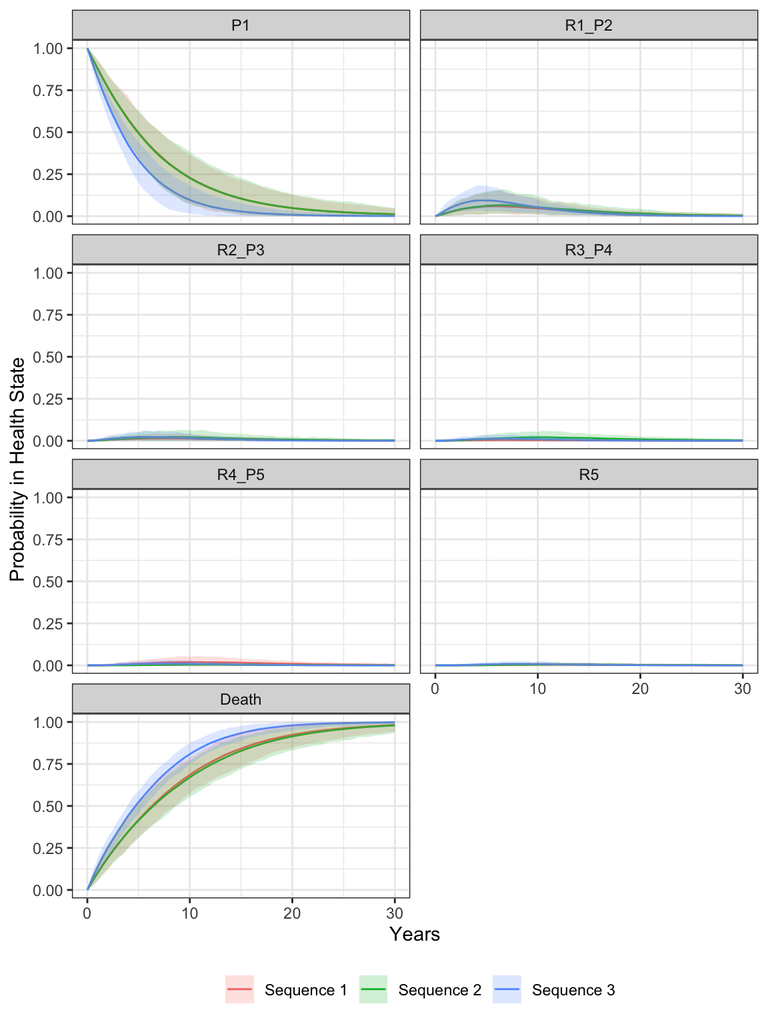

Figure 6.1: State Probabilities for Each Line of Treatment per Sequence

- This plot is saved to ../output/stprobs.pdf.

### 6.1.2 Time to Progression

Table 6.1: Table 6.2: Time to Progression (TTP) per Line of Treatment

| Strategy | % of initial pop | Transition | % who progressed | Median TTP | Mean TTP | 95% - CI |
| --- | --- | --- | --- | --- | --- | --- |
| 1 | 1.00 | 1 to 2 | 0.31 | 6.36 | 8.04 | (5.47, 11.43) |
| 1 | 0.31 | 2 to 3 | 0.61 | 1.60 | 2.46 | (1.72, 3.41) |
| 1 | 0.19 | 3 to 4 | 0.77 | 0.71 | 1.03 | (0.57, 1.66) |
| 1 | 0.15 | 4 to 5 | 0.88 | 0.32 | 0.37 | (0.28, 0.48) |
| 1 | 0.13 | 5 to 5+ | 0.56 | 1.26 | 2.07 | (0.93, 3.46) |
| 2 | 1.00 | 1 to 2 | 0.31 | 6.41 | 8.12 | (5.17, 11.67) |
| 2 | 0.31 | 2 to 3 | 0.59 | 1.82 | 2.79 | (1.83, 3.83) |
| 2 | 0.18 | 3 to 4 | 0.75 | 1.30 | 1.82 | (0.95, 3.1) |
| 2 | 0.14 | 4 to 5 | 0.88 | 2.12 | 2.45 | (1.49, 3.66) |
| 2 | 0.12 | 5 to 5+ | 0.69 | 0.27 | 0.44 | (0.22, 0.75) |
| 3 | 1.00 | 1 to 2 | 0.37 | 4.12 | 5.19 | (3.93, 6.66) |
| 3 | 0.37 | 2 to 3 | 0.60 | 1.55 | 2.41 | (1.73, 3.1) |
| 3 | 0.23 | 3 to 4 | 0.77 | 0.72 | 1.04 | (0.61, 1.75) |
| 3 | 0.18 | 4 to 5 | 0.89 | 0.65 | 0.77 | (0.4, 1.37) |
| 3 | 0.16 | 5 to 5+ | 0.67 | 0.40 | 0.69 | (0.37, 1.06) |

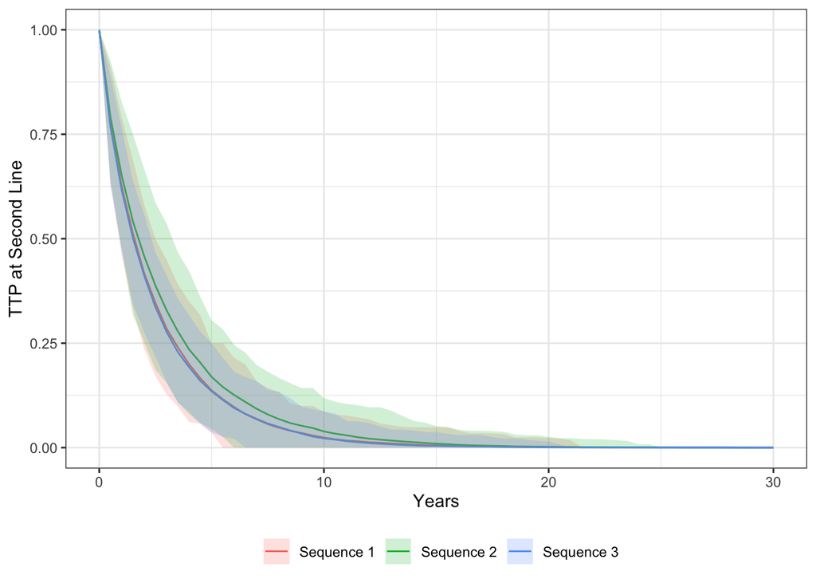

Figure 6.2: Time to Progression at Second Line

- This figure is saved to ../output/ttp2ndline.pdf.

### 6.1.3 Time to Death Pre-Progression

Table 6.3: Table 6.4: Time to death pre-pregression (TTDP) per line of treatment

| Strategy | % of initial pop | Transition | % who died | Median TTDP | Mean TTDP | 95% - CI |
| --- | --- | --- | --- | --- | --- | --- |
| 1 | 1.00 | 1 to D | 0.69 | 4.55 | 6.31 | (3.8, 9.07) |
| 1 | 0.31 | 2 to D | 0.39 | 1.96 | 2.87 | (1.76, 4.17) |
| 1 | 0.19 | 3 to D | 0.23 | 0.76 | 1.04 | (0.37, 1.96) |
| 1 | 0.15 | 4 to D | 0.12 | 0.25 | 0.27 | (0.07, 0.53) |
| 1 | 0.13 | 5 to D | 0.44 | 1.92 | 2.80 | (1.24, 4.45) |
| 1 | 0.07 | 5+ to D | 1.00 | 0.66 | 0.90 | (0.49, 1.42) |
| 2 | 1.00 | 1 to D | 0.69 | 4.45 | 6.25 | (3.74, 9.02) |
| 2 | 0.31 | 2 to D | 0.41 | 2.34 | 3.37 | (1.97, 5.05) |
| 2 | 0.18 | 3 to D | 0.25 | 1.30 | 1.73 | (0.58, 3.36) |
| 2 | 0.14 | 4 to D | 0.12 | 1.52 | 1.69 | (0.25, 3.67) |
| 2 | 0.12 | 5 to D | 0.31 | 0.38 | 0.54 | (0.18, 0.99) |
| 2 | 0.08 | 5+ to D | 1.00 | 0.65 | 0.89 | (0.54, 1.41) |
| 3 | 1.00 | 1 to D | 0.63 | 2.91 | 4.03 | (2.58, 5.56) |
| 3 | 0.37 | 2 to D | 0.40 | 1.96 | 2.81 | (1.89, 4.08) |
| 3 | 0.23 | 3 to D | 0.23 | 0.80 | 1.07 | (0.42, 1.95) |
| 3 | 0.18 | 4 to D | 0.11 | 0.50 | 0.57 | (0.12, 1.39) |
| 3 | 0.16 | 5 to D | 0.33 | 0.72 | 0.99 | (0.43, 1.68) |
| 3 | 0.10 | 5+ to D | 1.00 | 0.64 | 0.91 | (0.57, 1.37) |

### 6.1.4 Progression Free Survival

Table 6.5: Table 6.6: Progression free survival (PFS) per line of treatment

| Strategy | % of initial pop | LOT | Median PFS | Mean PFS | 95% - CI |
| --- | --- | --- | --- | --- | --- |
| 1 | 1.00 | 1 | 5.10 | 6.87 | (4.67, 9.3) |
| 1 | 0.31 | 2 | 1.72 | 2.62 | (1.96, 3.39) |
| 1 | 0.19 | 3 | 0.70 | 1.03 | (0.6, 1.61) |
| 1 | 0.15 | 4 | 0.31 | 0.36 | (0.27, 0.47) |
| 1 | 0.13 | 5 | 1.48 | 2.41 | (1.44, 3.57) |
| 1 | 0.07 | 5+ | 0.66 | 0.90 | (0.49, 1.42) |
| 2 | 1.00 | 1 | 5.04 | 6.84 | (4.77, 9.4) |
| 2 | 0.31 | 2 | 2.00 | 3.05 | (2.09, 4.12) |
| 2 | 0.18 | 3 | 1.25 | 1.81 | (0.94, 3.03) |
| 2 | 0.14 | 4 | 2.00 | 2.36 | (1.48, 3.59) |
| 2 | 0.12 | 5 | 0.29 | 0.48 | (0.25, 0.74) |
| 2 | 0.08 | 5+ | 0.65 | 0.89 | (0.54, 1.41) |
| 3 | 1.00 | 1 | 3.35 | 4.48 | (3.43, 5.59) |
| 3 | 0.37 | 2 | 1.69 | 2.57 | (2, 3.22) |
| 3 | 0.23 | 3 | 0.72 | 1.05 | (0.62, 1.68) |
| 3 | 0.18 | 4 | 0.62 | 0.75 | (0.38, 1.31) |
| 3 | 0.16 | 5 | 0.48 | 0.79 | (0.48, 1.17) |
| 3 | 0.10 | 5+ | 0.64 | 0.91 | (0.57, 1.37) |

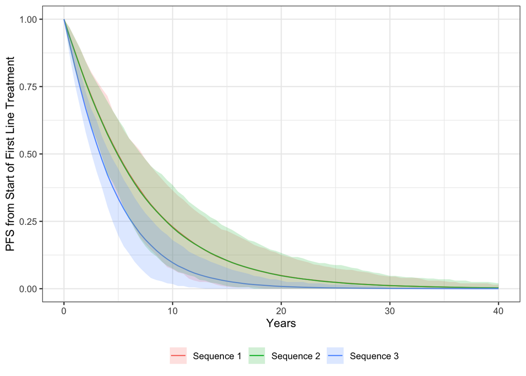

Figure 6.3: Progression Free Survival from Start of First Line Treatment

- This figure is saved to ../output/pfs1stline.pdf.

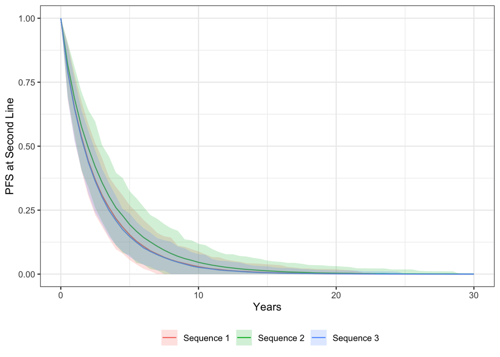

Figure 6.4: Progression Free Survival at Second Line

- This figure is saved to ../output/pfs2ndline.pdf.

### 6.1.5 Overall Survival

Table 6.7: Table 6.8: Overall survival from line of treatment

| Strategy | % of initial pop | LOT | Median OS | Mean OS | 95% - CI |
| --- | --- | --- | --- | --- | --- |
| 1 | 1.00 | 1 | 6.39 | 8.30 | (6.37, 10.87) |
| 1 | 0.31 | 2 | 3.69 | 4.65 | (3.61, 5.91) |
| 1 | 0.19 | 3 | 2.54 | 3.30 | (2.18, 4.71) |
| 1 | 0.15 | 4 | 2.14 | 2.95 | (1.92, 4.16) |
| 1 | 0.13 | 5 | 2.08 | 2.91 | (1.83, 4.22) |
| 1 | 0.07 | 5+ | 0.66 | 0.90 | (0.46, 1.56) |
| 2 | 1.00 | 1 | 6.51 | 8.56 | (6.54, 11.35) |
| 2 | 0.31 | 2 | 4.69 | 5.60 | (4.2, 7.36) |
| 2 | 0.18 | 3 | 3.83 | 4.30 | (2.94, 6.23) |
| 2 | 0.14 | 4 | 3.00 | 3.32 | (2.16, 5.01) |
| 2 | 0.12 | 5 | 0.83 | 1.09 | (0.67, 1.57) |
| 2 | 0.08 | 5+ | 0.65 | 0.89 | (0.43, 1.54) |
| 3 | 1.00 | 1 | 4.72 | 6.03 | (5.2, 6.89) |
| 3 | 0.37 | 2 | 3.43 | 4.13 | (3.27, 5.08) |
| 3 | 0.23 | 3 | 2.30 | 2.59 | (1.89, 3.63) |
| 3 | 0.18 | 4 | 1.72 | 2.00 | (1.43, 2.85) |
| 3 | 0.16 | 5 | 1.07 | 1.40 | (1.01, 1.99) |
| 3 | 0.10 | 5+ | 0.64 | 0.91 | (0.53, 1.45) |

- Summary tables with statistics on sojourn time between states (non-death and to death state) are saved to ../output/progressionTbl.xlsx.

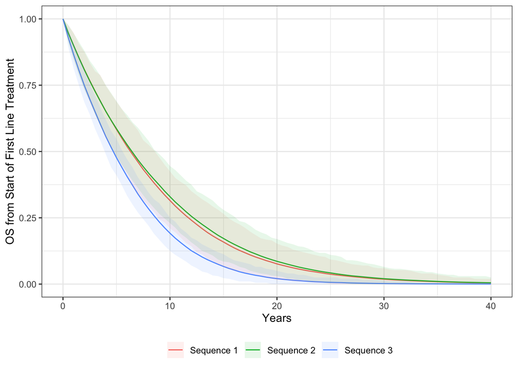

Figure 6.5: Overall Survival from Start of First Line Treatment

- This plot is saved to ../output/os1stline.pdf.

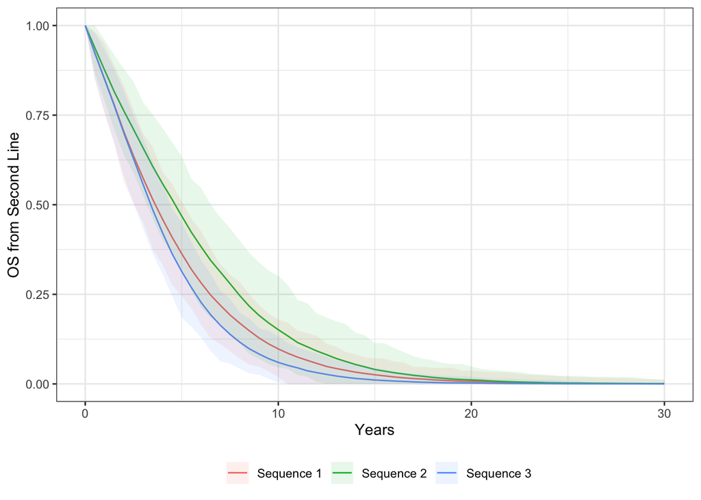

Figure 6.6: Overall Survival from Second Line

- This plot is saved to ../output/os2ndline.pdf.

## 6.2 QALYs and Costs

### 6.2.1 QALYs

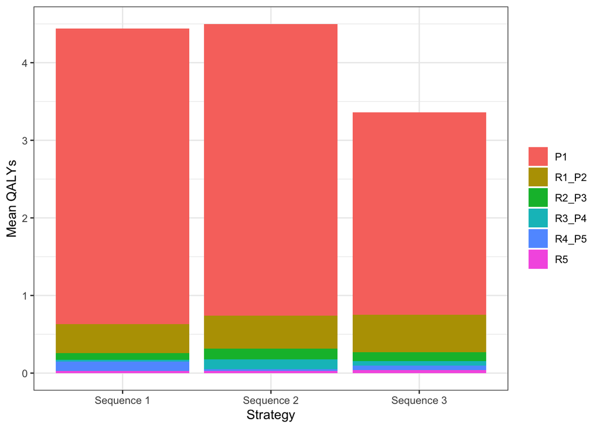

Figure 6.7: Expected QALYs by Treatment Sequence

### 6.2.2 Drug Treatment Costs

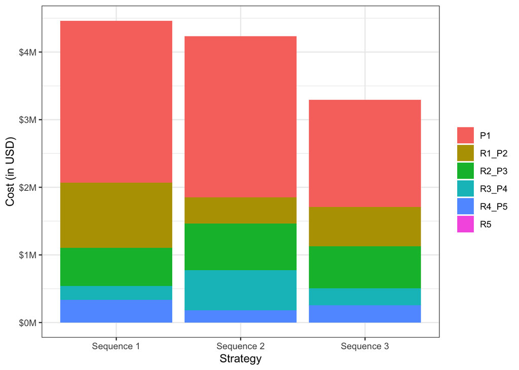

Figure 6.8: Expected Drug Treatment Costs

The next chunk saves the drug treatment cost chart to ../output/txcosts.pdf

### 6.2.3 Other Medical Costs

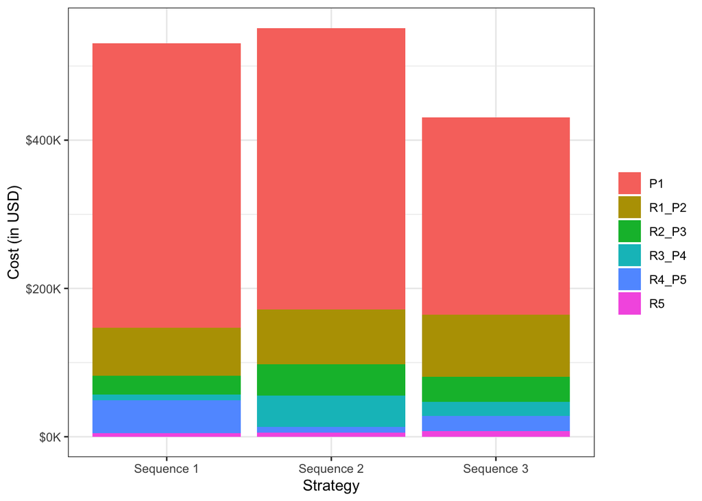

Figure 6.9: Expected Other Medical Costs

### 6.2.4 Total Costs

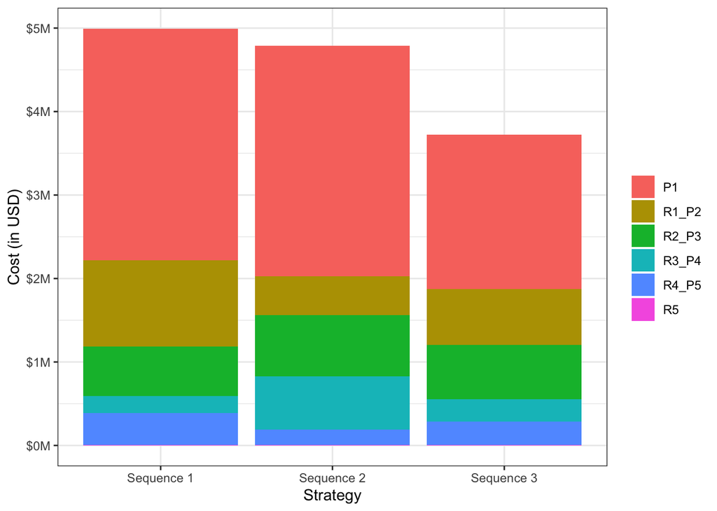

Figure 6.10: Expected Total Costs: Drug Costs plus Other Medical Costs

### 6.2.5 Summary of Model Outcomes

A summary table of expected QALYs and costs is saved to ../output/ce_sim_output.xlsx

Table 6.9: Table 6.10: Expected QALYs

| Outcome | Sequence 1 | Sequence 2 | Sequence 3 |
| --- | --- | --- | --- |
| QALYs | 4.44 (3.47, 5.56) | 4.50 (3.50, 5.69) | 3.36 (2.91, 3.80) |

Table 6.11: Table 6.12: Expected Costs

| Outcome | Sequence 1 | Sequence 2 | Sequence 3 |
| --- | --- | --- | --- |
| Inpatient | 243,999 (171,510, 338,912) | 253,102 (182,281, 340,269) | 198,997 (155,942, 247,366) |
| Outpatient | 200,019 (161,117, 242,537) | 208,631 (167,093, 253,087) | 160,934 (138,938, 188,311) |
| OtherOutRx | 81,504 (62,462, 103,682) | 84,217 (64,689, 107,427) | 62,797 (51,514, 74,242) |
| HOSPICE | 4,875 (922, 13,985) | 5,230 (903, 11,723) | 7,961 (2,224, 16,600) |
| Drug | 4,463,131 (3,798,351, 5,240,046) | 4,234,503 (3,457,551, 5,169,571) | 3,294,691 (2,816,429, 3,947,538) |
| Total | 4,993,528 (4,284,823, 5,834,840) | 4,785,682 (3,958,100, 5,760,207) | 3,725,381 (3,238,257, 4,369,998) |

# 7 Cost-Effectiveness Analysis

Table 7.1: Table 7.2: Cost-effectiveness analysis: K = 150000 Anchor sequence 3

| Outcome | Sequence 1 | Sequence 2 |
| --- | --- | --- |
| Incremental QALYs | 1.08 (0.08, 2.21) | 1.14 (0.19, 2.29) |
| Incremental costs | 1,268,148 (554,494, 2,052,677) | 1,060,301 (313,013, 1,946,401) |
| Incremental NMB | -1,106,507 (-1,731,961, -496,632) | -889,752 (-1,666,660, -244,156) |
| ICER | 1,176,818 | 932,545 |

## 7.1 Cost-effectiveness plane

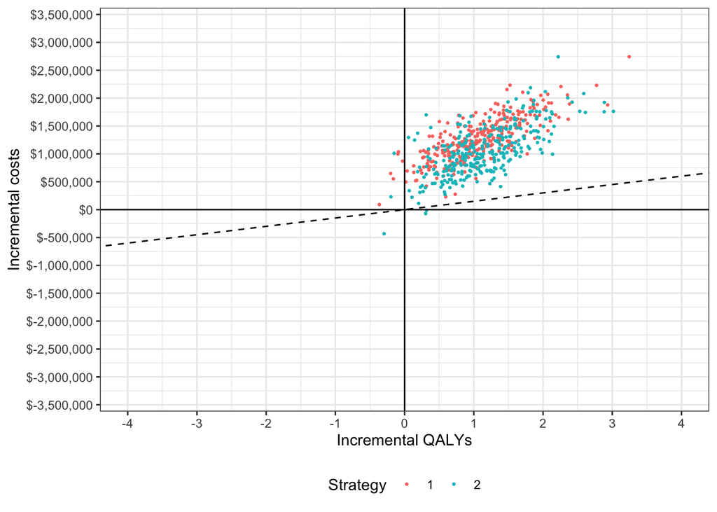

## 7.2 Acceptability curves

This plots provide a summary measure for quantifying uncertainty in terms of the probability that each strategy sequence is the most cost effective. These curves are derived from the simulation output as the proportion of simulation draws that each strategy has the highest net monetary benifit (NMB) estimate.

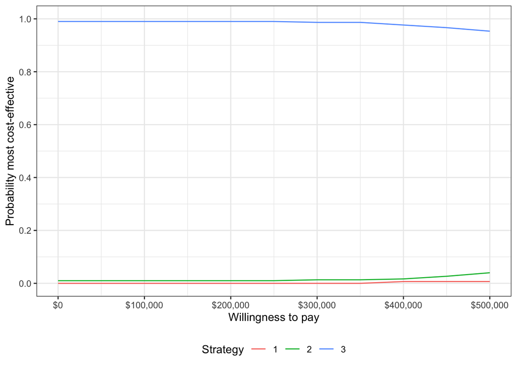

# References

Braunlin M, Belani R, Buchanan J, Wheeling T, Kim C. Trends in the multiple myeloma treatment landscape and survival: A US analysis using 2011–2019 oncology clinic electronic health record data. Leukemia & Lymphoma [Internet]. 2021;62(2):377–86. Available from: https://doi.org/10.1080/10428194.2020.1827253

Chari A, Vogl DT, Gavriatopoulou M, Nooka AK, Yee AJ, Huff CA, et al. Oral selinexor–dexamethasone for triple-class refractory multiple myeloma. New England Journal of Medicine [Internet]. 2019;381(8):727–38. Available from: https://doi.org/10.1056/NEJMoa1903455

Dimopoulos MA, Dytfeld D, Grosicki S, Moreau P, Takezako N, Hori M, et al. Elotuzumab plus pomalidomide and dexamethasone for multiple myeloma. New England Journal of Medicine [Internet]. 2018;379(19):1811–22. Available from: https://doi.org/10.1056/NEJMoa1805762

Moreau P, Garfall AL, Donk NWCJ van de, Nahi H, San-Miguel JF, Oriol A, et al. Teclistamab in relapsed or refractory multiple myeloma. New England Journal of Medicine [Internet]. 2022;387(6):495–505. Available from: https://doi.org/10.1056/NEJMoa2203478

Usmani SZ, Quach H, Mateos MV, Landgren O, Leleu X, Siegel D, et al. Carfilzomib, dexamethasone, and daratumumab versus carfilzomib and dexamethasone for patients with relapsed or refractory multiple myeloma (CANDOR): Updated outcomes from a randomised, multicentre, open-label, phase 3 study. The Lancet Oncology [Internet]. 2022;23(1):65–76. Available from: https://doi.org/10.1016/S1470-2045(21)00579-9

Voorhees PM, Kaufman JL, Laubach J, Sborov DW, Reeves B, Rodriguez C, et al. Daratumumab, lenalidomide, bortezomib, and dexamethasone for transplant-eligible newly diagnosed multiple myeloma: the GRIFFIN trial. Blood [Internet]. 2020 Aug;136(8):936–45. Available from: https://doi.org/10.1182/blood.2020005288